# STAT184 Final Project

Jongyoon Sohn

December 09, 2016

⇒ STAT184_Final.Rmd

# Purpose of project

It is widely known that Americans celebrate Thanksgiving Day since 1941 when President Franklin D. Roosevelt proposed and it was approved by the Congress. However, I started to think that not every american celebrates this day no matter what reasons they have and if they do, how they would spend the holiday. In this project, I asked myself a couple of questions that can be answered/obtained based on the data set in order to make its structure neat and show what decisions can be made.

```r
#reading the data set from the corresponding website
Thanksgiving<-mosaic::read.file("https://raw.githubusercontent.com/fivethirtyeight/data/master/thanksgiving-2015/thanksgiving-2015-poll-data.csv")
```

```
## Reading data with read.csv()
```

Before doing something, the names of columns are too long and complicated to understand so I will modify column names of data using names() function.

```r
#assign desired column names into a dummy value
Name<-c("ID","Celebrate","Main_dish","Main_dish(other)","Cooking_method","Cooking_method(other)","Stuffing","Stuffing(other)","Cranberry","Cranberry(other)","Gravy","SideDish1","SideDish2","SideDish3","SideDish4","SideDish5","SideDish6","SideDish7","SideDish8","SideDish9","SideDish10","SideDish11","SideDish12","SideDish13","SideDish(other1)","SideDish(other2)","Pie1","Pie2","Pie3","Pie4","Pie5","Pie6","Pie7","Pie8","Pie9","Pie10","Pie11","Pie(other1)","Pie(other2)","Dissert1","Dissert2","Dissert3","Dissert4","Dissert5","Dissert6","Dissert7","Dissert8","Dissert9","Dissert10","Dissert(other1)","Dissert(other2)","Pray","Travel","Program","Agecutoff","With_friends","Friendsgiving","BlackFriday","WorkRetail","WorkBF","Place","Age","Gender","Income","USRegion")
names(Thanksgiving)<-Name
```

In the result, short and representative column names are assigned into the original data set so that it would help readers read and understand the code being used much easier.

# Analysis 01

How many people among respondents for this survey celebrate Thanksgiving?

```r
Thanksgiving %>%
  group_by(Celebrate) %>%
  summarise(count=n())  #count the number of No's and Yes's
```

```
## # A tibble: 2 × 2
##   Celebrate count
##       <chr> <int>
## 1        No    78
## 2       Yes   980
```

Out of 1058 respondent people, 980 people celebrate Thanksgiving Day and 78 people do not. In fact, more than $\frac{980}{1058} = 92\%$ of people celebrate Thanksgiving.

# Analysis 02

Then, now how do they enjoy the day? What kind of food would be on the dinner table? In order to find out, I first need the information from those who celebrate the holiday. Otherwise, it would make no sense. So I created the Celebrating dataset that exclude rows in which people don’t celebrate Thanksgiving. Then the Celebrating dataset has been sorted by main dishes and plotted into a histogram.

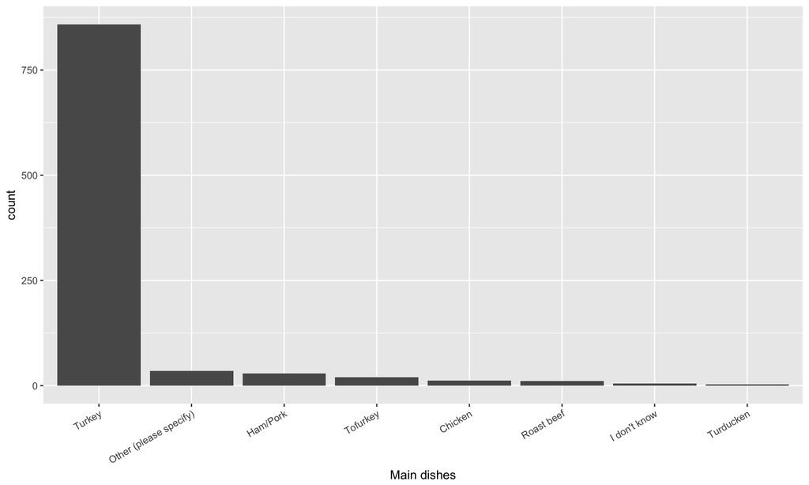

```r
#filter Yes's only
Celebrating <- Thanksgiving %>%
  filter(Celebrate=="Yes")
#Main dish preference
Celebrating %>%
  group_by(Main_dish) %>%
  summarise(count=n()) %>%
  filter(Main_dish!="") %>% #ignore non-responses
  arrange(desc(count)) %>%
  mutate(Main_dish=reorder(Main_dish,desc(count))) %>%
  ggplot(aes(x=Main_dish,y=count)) +
  geom_bar(stat="identity") +
  theme(axis.text.x=element_text(angle=30,hjust=1)) + #tilt the names of values to stop from overlap
  xlab("Main dishes")
```

```r
Celebrating %>%
  filter(Main_dish=="Turkey") %>%
  summarise(count=n())
```

```
##   count
## 1   859
```

According to the histogram, the majority of people who celebrate Thanksgiving have turkeys as the main dish with which $\frac{859}{980} = 87.65\%$ of those people argree. I don’t doubt why Thanksgiving has been called ‘Turkey Day’.

# Analysis 03

A lot of people celebrate Thankgiving and they have fun with their families/friends on the same day. I can’t imagine what the traffic would be like on the holiday. So this triggers a question that how many people would travel for Thanksgiving?

```r
Celebrating %>%
  group_by(Travel) %>%
  summarise(count=n()) %>%
  filter(Travel!="") %>% #ignore non-responses
  arrange(desc(count)) #descending order by count
```

```
## # A tibble: 4 × 2
##                                                                        Travel
##                                                                         <chr>
## 1                 Thanksgiving is happening at my home--I won't travel at all
## 2             Thanksgiving is local--it will take place in the town I live in
## 3 Thanksgiving is out of town but not too far--it's a drive of a few hours or
## 4 Thanksgiving is out of town and far away--I have to drive several hours or
## # ... with 1 more variables: count <int>
```

It seems that more than $80\%$ of people would stay at home or travel a little to celebrate Thanksgiving. Now, I’m wondering if your age and where you live would affect whether or not you are willing to travel for Thanksgiving.

```r
Celebrating %>%
  filter(Place!="") %>% #ignore non-responses
  filter(Travel!="") %>% #ignore non-responses
  group_by(Place,Travel) %>% #see the # of people who are in each combination of Place&Travel
  summarise(count=n())
```

```
## Source: local data frame [12 x 3]
## Groups: Place [?]
##
##       Place
##       <chr>
## 1     Rural
## 2     Rural
## 3     Rural
## 4     Rural
## 5  Suburban
## 6  Suburban
## 7  Suburban
## 8  Suburban
## 9     Urban
## 10    Urban
## 11    Urban
## 12    Urban
## # ... with 2 more variables: Travel <chr>, count <int>
```

In this table, you can see that how many people are travel or not depending on their living places. However, it is not easy to figure out which group of people(Place) would be more likely to travel given the table above. So histograms have been introduced to compare people consisting of each combination of Place and Travel.

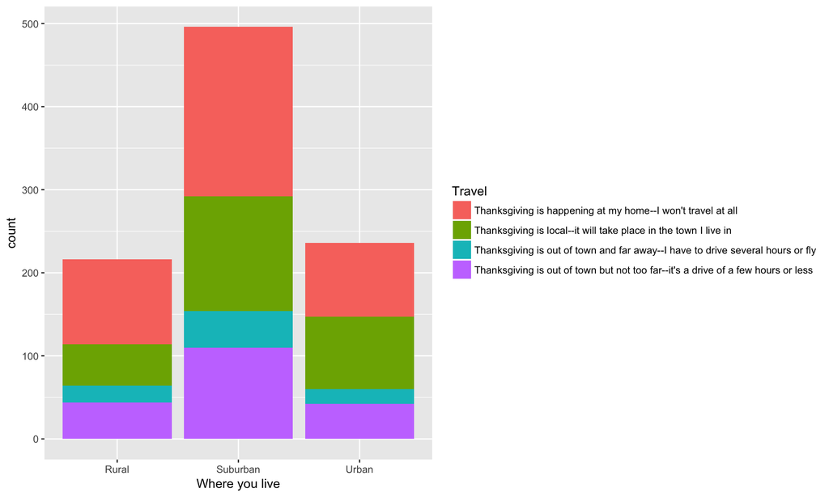

```r
Celebrating %>%
  filter(Place!="") %>% #ignore non-responses
  filter(Travel!="") %>% #ignore non-responses
  ggplot(aes(x=Place,fill=Travel)) +
  geom_bar() +
  xlab("Where you live")
```

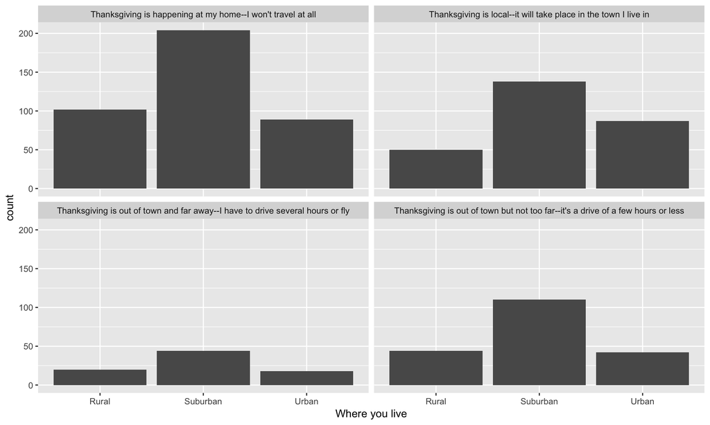

```r
Celebrating %>%
  filter(Place!="") %>% #ignore non-responses
  filter(Travel!="") %>% #ignore non-responses
  ggplot(aes(x=Place)) +
  geom_bar() +
  facet_wrap(~Travel) +
  xlab("Where you live")
```

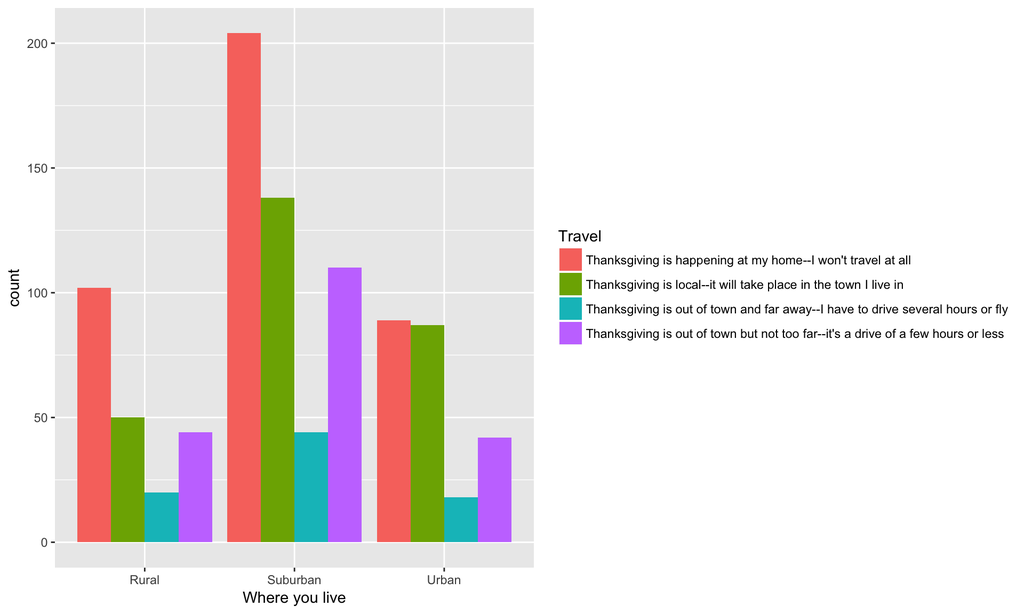

```r
Celebrating %>%
  filter(Place!="") %>% #ignore non-responses
  filter(Travel!="") %>% #ignore non-responses
  ggplot(aes(x=Place, fill=Travel)) +
  geom_bar(position="dodge") +
  xlab("Where you live")
```

Three different plots have been created using the same information but in different ways and I think that the plot in the last can be easily interpreted to compare the frequency of people who are traveling from each case of living places. For instance, urban people are likely to have Thanksgiving at home or somewhere in local with approximately equal percentages but the percentage of rural people who have Thanksgiving at home is about twice of the percentage of rural people who have Thanksgiving in local.

# Analysis 04

In the previous question, I looked at the frequencies of traveling depending on where you live. But, it made me think of another possibility that the age would be another factor that influences the decision whether you travel for Thanksgiving. Maybe, the older you get, the much eagerly you are to stay. So, a similar method is used here to the same plots.

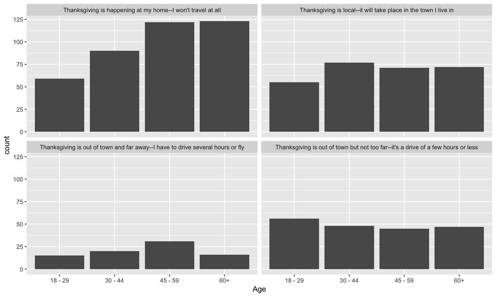

```r
Celebrating %>%
  filter(Age!="") %>% #ignore non-responses
  filter(Travel!="") %>% #ignore non-responses
  ggplot(aes(x=Age)) +
  geom_bar() +
  facet_wrap(~Travel)
```

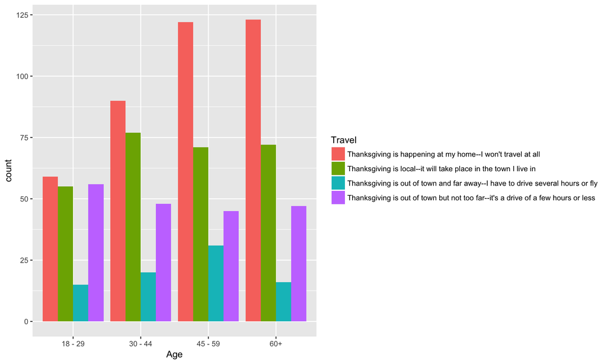

```r
Celebrating %>%
  filter(Age!="") %>% #ignore non-responses
  filter(Travel!="") %>% #ignore non-responses
  ggplot(aes(x=Age, fill=Travel)) +
  geom_bar(position="dodge")
```

```r
Celebrating %>%
  filter(Age!="") %>% #ignore non-responses
  filter(Travel!="") %>% #ignore non-responses
  group_by(Age,Travel) %>% #see the # of people who are in each combination of Age&Travel
  summarise(count=n())
```

```
## Source: local data frame [16 x 3]
## Groups: Age [?]
##
##        Age
##      <chr>
## 1  18 - 29
## 2  18 - 29
## 3  18 - 29
## 4  18 - 29
## 5  30 - 44
## 6  30 - 44
## 7  30 - 44
## 8  30 - 44
## 9  45 - 59
## 10 45 - 59
## 11 45 - 59
## 12 45 - 59
## 13     60+
## 14     60+
## 15     60+
## 16     60+
## # ... with 2 more variables: Travel <chr>, count <int>
```

# Analysis 05

What is the favorite side dishes for respondents’ states? First, I need to see how many different regions consist of the poll by using the group_by().

```r
Celebrating %>%
  filter(USRegion!="") %>% #ignore non-responses
  group_by(USRegion) %>%
  summarise(count=n())
```

```
## # A tibble: 9 × 2
##             USRegion count
##                <chr> <int>
## 1 East North Central   145
## 2 East South Central    56
## 3    Middle Atlantic   145
## 4           Mountain    41
## 5        New England    55
## 6            Pacific   130
## 7     South Atlantic   203
## 8 West North Central    71
## 9 West South Central    85
```

There are 931 people who answer among the sample(excluding non exsistent entries) and the distribution of population looks like this.

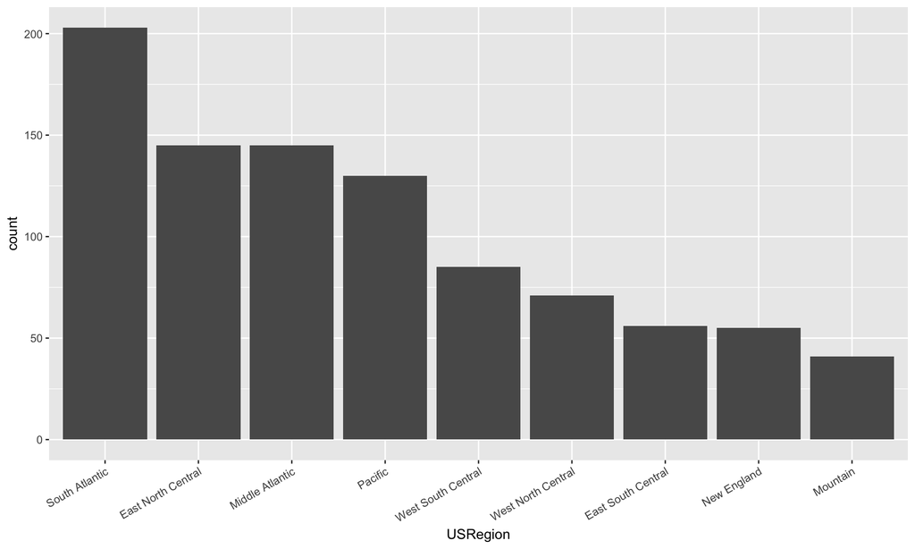

```r
Celebrating %>%
  group_by(USRegion) %>%
  summarise(count=n()) %>%
  filter(USRegion!="") %>% #ignore non-responses
  arrange(desc(count)) %>%
  mutate(USRegion=reorder(USRegion,desc(count))) %>%
  ggplot(aes(x=USRegion,y=count)) +
  geom_bar(stat="identity") +
  theme(axis.text.x=element_text(angle=30,hjust=1)) #tilt the names of values to stop from overlap
```

As an example, South Atlantic is selected to see how many people are enjoying which side dishes. Since I wanted to create a new table that has variables of side dishes and count and the respondents had multiple answers for each side dish, I should follow these steps.

```r
a1<-Celebrating %>%
  filter(USRegion == "South Atlantic") %>%
  group_by(SideDish1) %>%
  summarise(count=n())
names(a1)<-c("SideDish","Count")
a2<-Celebrating %>%
  filter(USRegion == "South Atlantic") %>%
  group_by(SideDish2) %>%
  summarise(count=n())
names(a2)<-c("SideDish","Count")
a3<-Celebrating %>%
  filter(USRegion == "South Atlantic") %>%
  group_by(SideDish3) %>%
  summarise(count=n())
names(a3)<-c("SideDish","Count")
a4<-Celebrating %>%
  filter(USRegion == "South Atlantic") %>%
  group_by(SideDish4) %>%
  summarise(count=n())
names(a4)<-c("SideDish","Count")
a5<-Celebrating %>%
  filter(USRegion == "South Atlantic") %>%
  group_by(SideDish5) %>%
  summarise(count=n())
names(a5)<-c("SideDish","Count")
a6<-Celebrating %>%
  filter(USRegion == "South Atlantic") %>%
  group_by(SideDish6) %>%
  summarise(count=n())
names(a6)<-c("SideDish","Count")
a7<-Celebrating %>%
  filter(USRegion == "South Atlantic") %>%
  group_by(SideDish7) %>%
  summarise(count=n())
names(a7)<-c("SideDish","Count")
a8<-Celebrating %>%
  filter(USRegion == "South Atlantic") %>%
  group_by(SideDish8) %>%
  summarise(count=n())
names(a8)<-c("SideDish","Count")
a9<-Celebrating %>%
  filter(USRegion == "South Atlantic") %>%
  group_by(SideDish9) %>%
  summarise(count=n())
names(a9)<-c("SideDish","Count")
a10<-Celebrating %>%
  filter(USRegion == "South Atlantic") %>%
  group_by(SideDish10) %>%
  summarise(count=n())
names(a10)<-c("SideDish","Count")
a11<-Celebrating %>%
  filter(USRegion == "South Atlantic") %>%
  group_by(SideDish11) %>%
  summarise(count=n())
names(a11)<-c("SideDish","Count")
a12<-Celebrating %>%
  filter(USRegion == "South Atlantic") %>%
  group_by(SideDish12) %>%
  summarise(count=n())
names(a12)<-c("SideDish","Count")
a13<-Celebrating %>%
  filter(USRegion == "South Atlantic") %>%
  group_by(SideDish13) %>%
  summarise(count=n())
names(a13)<-c("SideDish","Count")
a<-rbind(a1,a2,a3,a4,a5,a6,a7,a8,a9,a10,a11,a12,a13)
a %>%
  filter(SideDish!="") %>%
  arrange(desc(Count))
```

```
## # A tibble: 13 × 2
##                            SideDish Count
##                               <chr> <int>
## 1                    Rolls/biscuits   158
## 2                   Mashed potatoes   157
## 3  Green beans/green bean casserole   150
## 4       Yams/sweet potato casserole   144
## 5                              Corn    96
## 6               Macaroni and cheese    79
## 7                         Cornbread    53
## 8                           Carrots    48
## 9                       Fruit salad    39
## 10                  Vegetable salad    39
## 11                           Squash    31
## 12                  Brussel sprouts    27
## 13                      Cauliflower    11
```

In each step, I created a new table that has a corresponding side dish with the count and combine all of the tables from steps that have been made the same way in order to show their side foods preferences. Most people living in the South Atlantic region love to eat Rolls/biscuits, Mashed potatoes, Green beans, and Yams/casserole than other sides. Now, you are able to figure out local people’s favorite sides in the same way for each region.

# Wrapping up

This project is presenting people’s overall preferences about Thanksgiving such as likelihood of celebrating, traveling and their favorite Thanksgiving foods. I chose this subject because I wanted to learn more about American culture and how people spend one of holidays in America. Great chance of taking a look at their culture and new findings from a solid data set.